# Set Up Command Line Software for Agentic Workflows

Hands-on · Day 0 · Setup for AI-enabled Research

Kristoffer Bjärkefur & Mer Reyes Retana

Impact Analytics

1 October 2026

## Objective

- Install software used by the agent
- Make those software accessible from the command line - where the agent can find them

### One note on vocabulary

In guides and documentation related to this, you will see both the terms “**command line**” and “**terminal**”.

Those terms are related, and for the purpose of this training, those two terms will be considered equivalent. You will see and hear us use those terms interchangeably.

## Why does the agent need software you don’t use?

- The agent works by **running programs on your computer**, and it picks the right tool for each task.
- Those tools are often **different from the ones you use every day**. For example, agents use Python to read PDF and Word files, even if your project is entirely in Stata.
- So we install a small set of tools that agents commonly call, and make sure the agent can **reach** them.

## What does “reachable from the command line” mean?

- When you **click** an app, your computer already knows where it is installed.
- On the **command line**, you only type a program’s name. The computer finds it by searching a list of folders called the **PATH**.
- So software can be installed and work fine when you click it, but **fail from the command line** if its folder is not in the PATH.
- The agent works **only from the command line**, so your software must be in the PATH.

## Command Line Access

Why is command line (or terminal) access important?

- The more the agent use tools on your computer, the more token efficient. Extract text on your computer from a PDF is cheaper than sending the file to the cloud.
- The agent cannot open point-and-click software windows – instead it sends commands via the command line
- Under the hood, it is the same software running the task – the only difference is how the task was initiated.
- The agent can also use command line access to test its own solution before returning the result to you – important for ensuring quality.

[figure not shown]

## What’s required for who

We will use the command line (or terminal) this session to verify that installations are accessible from the command line. But then we will not rely on it during the rest of the training.

### Required for everyone:

- **Python** installed and accessible from the command line
  - We recommend this even if none of your projects require Python. Agents default to Python for many tasks, such as parsing PDF and Word files.
- Either **Quarto** or **LaTeX** installed and accessible from the command line
  - Several sessions require this, particularly on Days 2 and 3.

### Required if your specific project uses it:

- **R** installed and accessible from the command line

## Opening the Default Terminal

Your agent will use the default terminal configured in VS Code.

Therefore, software must be available from that terminal for this training.

To open it, go to the top menu and select “Terminal”, then “New Terminal”.

Type the verification commands on the next slide into the terminal and press Enter.

The folder location does not matter when running these specific commands.

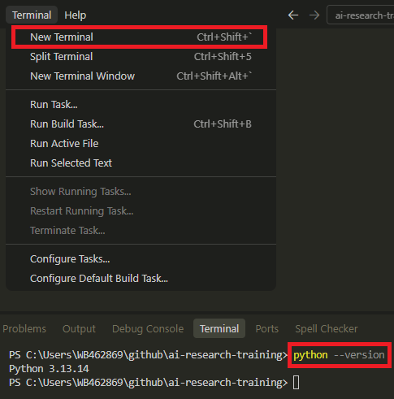

## Verifying installations in the command line

Open the default terminal (as shown in the previous slide) and run these commands in the default terminal (also shown in the previous slide) to verify command line access.

- **Python**. Command to verify command line access: `python --version` -> expected output: `Python 3.*.*`
- **R**. Command to verify command line access: `R --version` -> expected output: `R version 4.*.* [...]` followed by R’s copyright information
- **Quarto**. Command to verify command line access: `quarto --version` -> expected output: `1.*.*`
- **LaTeX compiler**. Command to verify command line access: `latex --version` -> output is usually verbose and differ between different LaTeX distributions. Expect a LaTeX compiler name, such as `pdfTeX 3.*.*` or `MiKTeX *.*.*`.

## Installing Python - WB Computer

1. Open Company Portal from the Start menu (on a Mac, open Self Service+) and search for “Python”.
2. Select Python and click “Install”.
3. Then verify that Python is available in the command line. Command to verify command line access: `python --version` -> expected output: `Python 3.*.*`

If the installation seemed successful but the verification command does not return the expected output (for example, it shows an error instead of a version number), follow the instructions on the slide Adding software to the system path - Windows or - Mac.

**Also:** submit a [Software Installation eServices Request](https://worldbankgroup.service-now.com/wbg?id=wbg_sc_cat_item_guide&sys_id=e643726c1bb73ed02685c8c5624bcbfb) noting you installed Python yourself. This is expected even for self-installs, and it helps ITS understand demand and allocate resources to support Python users.

## Installing Python - Personal Computer

1. Go to https://www.python.org/downloads/ and follow the instructions for your operating system.
2. Download and install the appropriate Python distribution, following the prompts.
3. Then verify that Python is available in the command line. Command to verify command line access: `python --version` -> expected output: `Python 3.*.*`

If the installation seemed successful but the verification command does not return the expected output (for example, it shows an error instead of a version number), follow the instructions on the slide Adding software to the system path - Windows or - Mac. On a personal computer you can also use the agent or an AI ChatBot to find how to add Python to your computer’s path variable.

## Installing LaTeX - WB Computer

1. Open Company Portal from the Start menu (on a Mac, open Self Service+) and search for “MiKTeX”.
2. Select MiKTeX and click “Install”.
3. Then verify that LaTeX is available in the command line. Command to verify command line access: `latex --version` -> output is usually verbose and differ between different LaTeX distributions. Expect a LaTeX compiler name, such as `pdfTeX 3.*.*` or `MiKTeX *.*.*`.

If the installation seemed successful but the verification command does not return the expected output (for example, it shows an error instead of a version number), follow the instructions on the slide Adding software to the system path - Windows or - Mac.

**Also:** submit a [Software Installation eServices Request](https://worldbankgroup.service-now.com/wbg?id=wbg_sc_cat_item_guide&sys_id=e643726c1bb73ed02685c8c5624bcbfb) noting you installed MiKTeX yourself. This is expected even for self-installs, and it helps ITS understand demand and allocate resources to support MiKTeX users.

## Installing LaTeX - Personal Computer

1. Go to https://www.latex-project.org/get/#tex-distributions and follow the instructions for your operating system.
2. Download and install the appropriate LaTeX distribution, following the prompts.
3. Then verify that LaTeX is available in the command line. Command to verify command line access: `latex --version` -> output is usually verbose and differ between different LaTeX distributions. Expect a LaTeX compiler name, such as `pdfTeX 3.*.*` or `MiKTeX *.*.*`.

If the installation seemed successful but the verification command does not return the expected output (for example, it shows an error instead of a version number), follow the instructions on the slide Adding software to the system path - Windows or - Mac. On a personal computer you can also use the agent or an AI ChatBot to find how to add MiKTeX to your computer’s path variable.

## Installing Quarto - WB Computer

1. Open Company Portal from the Start menu and search for “Quarto”.
2. Select the Quarto application and click “Install”.
3. Then verify that Quarto is available in the command line. Command to verify command line access: `quarto --version` -> expected output: `1.*.*`

If the installation seemed successful but the verification command does not return the expected output (for example, it shows an error instead of a version number), follow the instructions on the slide Adding software to the system path - Windows or - Mac.

**Also:** submit a [Software Installation eServices Request](https://worldbankgroup.service-now.com/wbg?id=wbg_sc_cat_item_guide&sys_id=e643726c1bb73ed02685c8c5624bcbfb) noting you installed Quarto yourself. This is expected even for self-installs, and it helps ITS understand demand and allocate resources to support Quarto users.

## Installing Quarto - Personal Computer

1. Go to https://quarto.org/docs/get-started/ and follow the instructions for your operating system.
2. Download and install the appropriate Quarto distribution, following the prompts.
3. Then verify that Quarto is available in the command line. Command to verify command line access: `quarto --version` -> expected output: `1.*.*`

If the installation seemed successful but the verification command does not return the expected output (for example, it shows an error instead of a version number), follow the instructions on the slide Adding software to the system path - Windows or - Mac. On a personal computer you can also use the agent or an AI ChatBot to find how to add Quarto to your computer’s path variable.

## Installing R - WB Computer

1. Open Company Portal from the Start menu. Search for “RforWindows”.
2. Select the “RforWindows” application and click “Install”.
3. Then verify that R is available in the command line. Command to verify command line access: `R.exe --version` -> expected output: `R version 4.*.* [...]` followed by R’s copyright information

If the installation seemed successful but the verification command does not return the expected output (for example, it shows an error instead of a version number), follow the instructions on the slide Adding software to the system path - Windows or - Mac.

**Also:** submit a [Software Installation eServices Request](https://worldbankgroup.service-now.com/wbg?id=wbg_sc_cat_item_guide&sys_id=e643726c1bb73ed02685c8c5624bcbfb) noting you installed R yourself. This is expected even for self-installs, and it helps ITS understand demand and allocate resources to support R users.

## Installing R - Personal Computer

1. Go to https://cran.r-project.org/ and follow the instructions for your operating system.
2. Download and install the appropriate R version for your operating system, following the prompts.
3. Verify that R is available from the command line. Command to verify command line access: `R --version` -> expected output: `R version 4.*.* [...]` followed by R’s copyright information

If the installation seemed successful but the verification command does not return the expected output (for example, it shows an error instead of a version number), follow the instructions on the slide Adding software to the system path - Windows or - Mac. On a personal computer you can also use the agent or an AI ChatBot to find how to add R to your computer’s path variable.

If desired, you may also download and install RStudio as your R code editor, but the agent will not access R through RStudio.

## Adding software to the system path - Windows

*For a WB Windows Computer, you must follow this procedure:*

1. In the Start menu, search for “Edit environment variables for your account” and select it.
2. In the User variables box, select “Path” and click “Edit”.
3. Click “New” and add the folder where the software is installed (common locations on the next slide).
4. Then click “OK” in both boxes to save the changes.
5. Close and reopen VS Code, then verify that the software is available in the terminal.

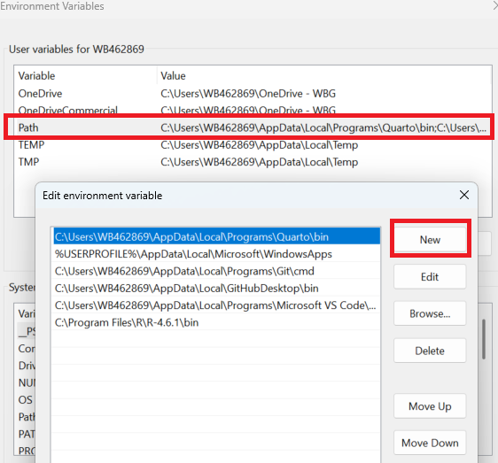

If you are using a personal computer, search online or ask an AI chatbot how to add the specific software to your computer’s system PATH.

## Where is the software installed? (WB Windows computers)

These are common installation folders on WB computers. **Confirm that the folder exists on your computer** (open it in File Explorer) before adding it to the PATH.

[output not shown]

## Adding software to the system path - Mac

**On a Mac, installers usually set this up for you.** Only follow these steps if the verification command fails.

1. In the VS Code terminal, run `touch ~/.zprofile && open -e ~/.zprofile` to open your shell settings file.
2. Add this line at the end, using the folder where the software is installed: `export PATH="$PATH:/folder/where/software/is"`
3. Save the file, close and reopen VS Code, then verify that the software is available in the terminal.

## Where is the software installed? (Mac)

**Confirm the folder exists on your Mac** (run `ls /the/folder`) before adding it to the PATH. To see where a program is, run `which quarto`.

| Software | Common folder |
| --- | --- |
| Python (python.org) | `/Library/Frameworks/Python.framework/Versions/3.13/bin` (the version number changes) |
| Quarto | `/Applications/quarto/bin` |

The R installer already links `R` into `/usr/local/bin`, which is on the PATH by default, so R rarely needs this.

**LaTeX on a Mac:** MiKTeX may not make `latex` available from the command line after installing. Quarto alone meets the requirement, so on a Mac we recommend Quarto instead of LaTeX.